# survivoR project

Carrie Snodgrass and Lilly Nikkel

3/29/2022

## Introduction

*Survivor* is one of the longest-running reality TV shows, premiering in 2000 with 42 seasons up to date. The basic premise of the game is that, in each episode, the contestants, or castaways vote to eliminate one player, and the last castaway remaining is the winner. We found a data set with data from the 1st through 40th seasons. The data set is focused on the castaways, with information based on their person hoods, such as age and hometown, and information based on their performance, such as where they placed and how many votes they received throughout the game. We want to determine what factors have the greatest effect, if any, on how well a castaway performs during the show

## Exploratory Data Analysis

The data set we used has most basic relevant data. We wish there were some other basic data included, like contestant gender, or hidden immunity idols. The data set also included qualitative data irrelevant to our analysis, such as tribe name and tribes switched.

### A Regression of Order Voted on Immunity Idols Won (from challenges)

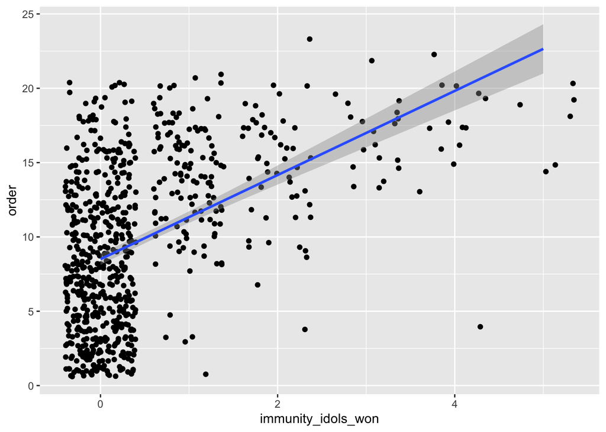

Each day in the season, contestants compete in a “challenge;” the winner of a any challenge gets an immunity idol which gives them “immunity” from being voted off for that day.

The order refers to the order in which contestants were voted off; a higher order number means that the contestant survived longer.

We used geom_jitter so that we could accurately see the distribution of contestants who won each number of immunity idols, since both the number of immunity idols and the order voted off are discrete variables.

This graph clearly sugggests that winning more immunity idols is associated with staying on the show longer.

### Regresssion of Total Votes Received on Immunity Idols Won

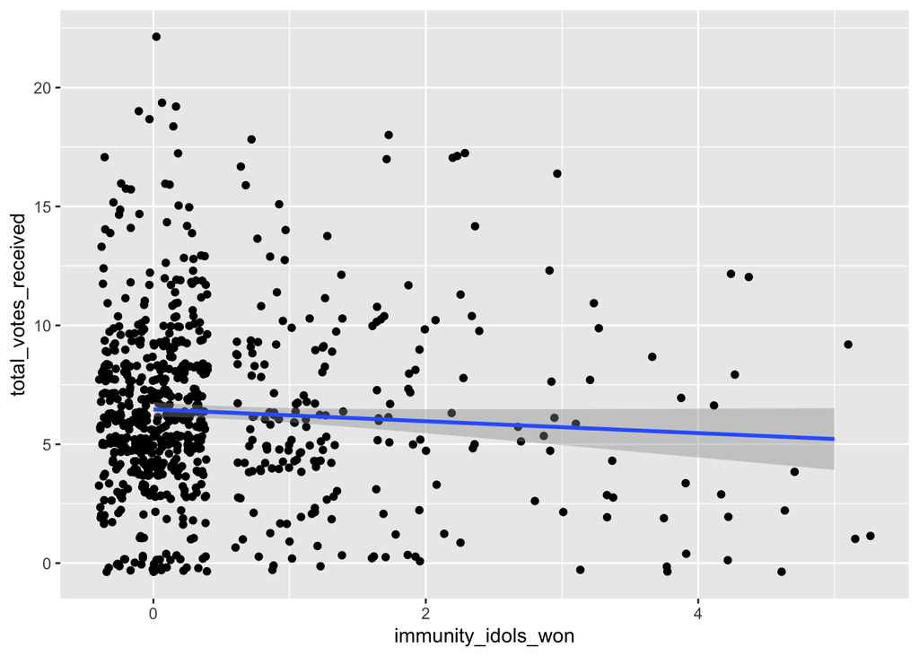

Total Votes Received is the total number of votes cast against a player throughout the season.

We plotted immunity idols won against total votes received (and plotted a regression line) to see if immunity idols won had any impact on how other contestants viewed that player (demonstrated by whether or not they were voted for in other rounds)

We used geom_jitter here again so that we could accurately see the distribution of contestants who won each number of immunity idols and who received each number of votes, since both the number of immunity idols and the number of votes received are discrete variables.

The graph suggests that there may be weak negative correlation between the two variables, if any at all.

### Distribution of Personality Types

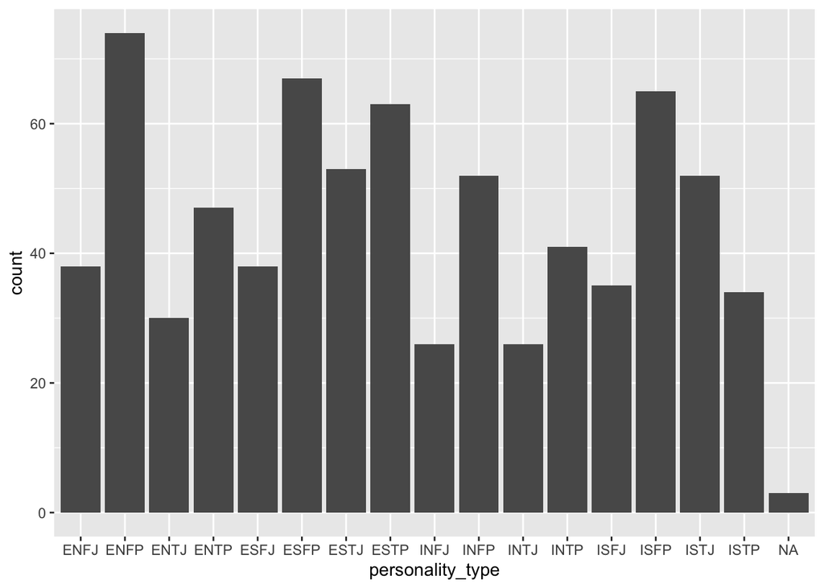

Our data set included the Meyers-Briggs personality type of each contestant.The Meyers-Briggs Personality Test assigns a personality type based on four traits: extraversion vs introversion; sensing vs intuition; thinking vs feeling; and judging vs perceiving. It should be noted that the methodologies for how the contestants were typed is unknown. We proceed with caution.

This bar graph visualizes the distribution of personality types represented by all of the contestants.

### A Regression of Order On Age

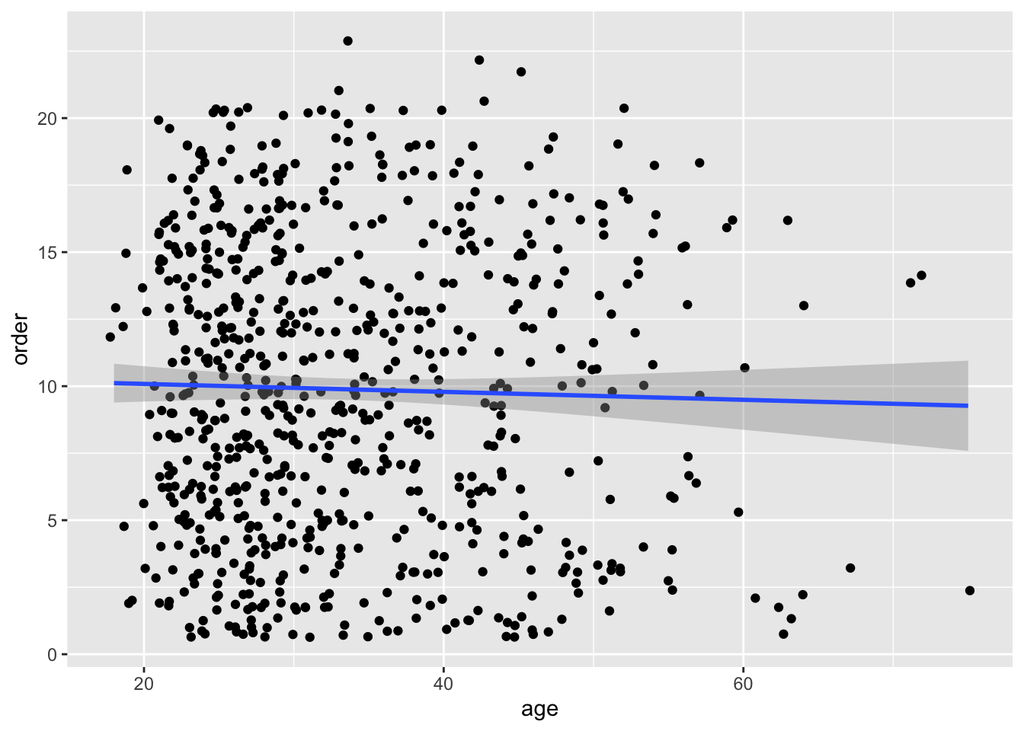

We plotted order against age (and plotted a regression line) to see if a contestant’s age (at the time of competition) had any impact on how long a contestant lasted on the show.

We used geom_jitter here again so that we could accurately see the distribution of the elimination order of contestants at each age, since both age and order are discrete variables.

The graph suggests that there may be weak negative correlation between the two variables, if any at all.

### Plotting Viewership by Season

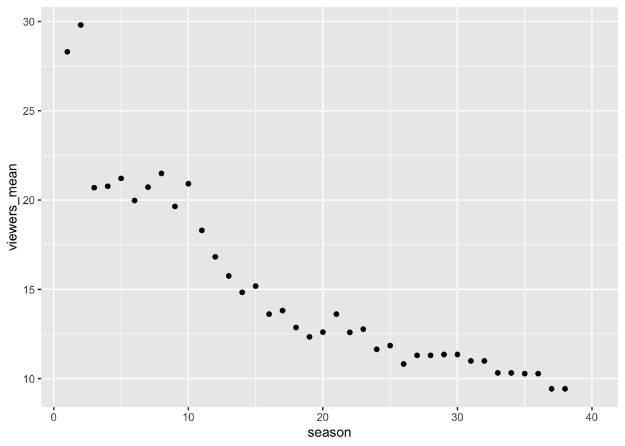

We also have data on viewership for each season; we plotted mean viewership by season, and we can see a clear descending trend. We chose not to pursue working with this data.

## Statistical Analysis

### Hypothesis Testing for Regression Coefficients (Order on Immunity Idols Won)

```
##
## Call:
## lm(formula = order ~ immunity_idols_won, data = castaways)
##
## Residuals:
##     Min      1Q  Median      3Q     Max
## -15.822  -3.505  -0.420   3.495  11.495
##
## Coefficients:
##                    Estimate Std. Error t value Pr(>|t|)
## (Intercept)          8.5054     0.1973   43.11   <2e-16 ***
## immunity_idols_won   2.8291     0.1832   15.44   <2e-16 ***
## ---
## Signif. codes:  0 '***' 0.001 '**' 0.01 '*' 0.05 '.' 0.1 ' ' 1
##
## Residual standard error: 4.798 on 742 degrees of freedom
## Multiple R-squared:  0.2432, Adjusted R-squared:  0.2422
## F-statistic: 238.5 on 1 and 742 DF,  p-value: < 2.2e-16
```

```
## [1] 0.4931756
```

In this hypothesis test, we are investigating whether winning immunity idols has an effect on the order a contestant is voted off. We start with the equation

order<sub>i</sub> = b<sub>0</sub> + b<sub>1</sub>immunity_idols_won.

We perform a hypothesis test based on the regressions visualized in the section entitled *A Regression of Order Voted on Immunity Idols Won (from challenges)*.

Therefore, our null hypothesis is that the number of immunity idols won has no effect on the order a contestant is voted off (H<sub>0</sub>: b<sub>1</sub> = 0), Our alternative hypothesis is that the number of immunity idols won does have an effect on the order a player is voted off (H<sub>a</sub>: b<sub>1</sub> ≠ 0).

The p-value for this test is less than .01, so we can reject the null hypothesis (that immunity idols won has no effect on order) at any standard level of confidence.

This makes sense, because winning an immunity idol means that the contestant will automatically stay an additional day.

It is interesting to note that the estimated coefficient on immunity idols is 2.8, which suggests that each additional immunity idol won is associated with an additional 2.8 days on the show.

The multiple R<sup>2</sup> is .24, which means that 24.32% of the variation in order can be explained by our model.

The correlation between immunity idols won and order is .493.

### Survivor x Meyers-Briggs Analysis

```
##
## Call:
## lm(formula = order ~ extraversion + intuitive + thinking + judging,
##     data = castaways)
##
## Residuals:
##     Min      1Q  Median      3Q     Max
## -9.4181 -4.6830 -0.0997  4.4964 13.4164
##
## Coefficients:
##               Estimate Std. Error t value Pr(>|t|)
## (Intercept)   10.50359    0.49025  21.425   <2e-16 ***
## extraversionI -0.21899    0.40807  -0.537    0.592
## intuitiveS    -0.51609    0.40941  -1.261    0.208
## thinkingT     -0.08552    0.40997  -0.209    0.835
## judgingP      -0.31838    0.41774  -0.762    0.446
## ---
## Signif. codes:  0 '***' 0.001 '**' 0.01 '*' 0.05 '.' 0.1 ' ' 1
##
## Residual standard error: 5.518 on 736 degrees of freedom
##   (3 observations deleted due to missingness)
## Multiple R-squared:  0.003215,   Adjusted R-squared:  -0.002202
## F-statistic: 0.5935 on 4 and 736 DF,  p-value: 0.6674
```

We separated the 4 personality traits of the Meyers-Briggs Personality types into individual dummy variables and ran a regression using just those so we could investigate how each pair of traits affects a contestant’s performance.

order<sub>i</sub> = b<sub>0</sub> + b<sub>1</sub>extraversion<sub>i</sub> + b<sub>2</sub>intuitive<sub>i</sub> + b<sub>3</sub>thinking<sub>i</sub> +b<sub>4</sub>judging<sub>i</sub>

Therefore, our null hypothesis is that each of the personality traits has no effect on the order a contestant is voted off (H<sub>0</sub>: b<sub>i</sub> = 0 for all *i*), Our alternative hypothesis is that one or more personality traits has an effect on the order a player is voted off (H<sub>a</sub>: b<sub>i</sub> ≠ 0 for at least 1 *i*.).

The coefficients on each of the variables can be found in the table.

The p-value for the coefficient on extraversion vs introversion is 0.592. The p-value for the coefficient on intuitive vs sensing is 0.208. The p-value for the coefficient on thinking vs feeling is .835. The p-value for the coefficient on judging vs perceiving is .446.

The p-values for each coefficient are greater than .05, so we fail to reject our null hypothesis that each of the personality traits has no effect on order voted off.

This test suggests that the Meyers Briggs personality traits do not have much of an effect on how well contestants do in Survivor.

```
##
## Call:
## lm(formula = order ~ age + extraversion + intuitive + thinking +
##     judging + immunity_idols_won + total_votes_received, data = castaways)
##
## Residuals:
##      Min       1Q   Median       3Q      Max
## -16.1870  -3.7278  -0.2318   3.5175  12.3798
##
## Coefficients:
##                       Estimate Std. Error t value Pr(>|t|)
## (Intercept)           9.484210   0.839416  11.299   <2e-16 ***
## age                  -0.005828   0.018306  -0.318   0.7503
## extraversionI        -0.236293   0.354372  -0.667   0.5051
## intuitiveS           -0.674187   0.358142  -1.882   0.0602 .
## thinkingT            -0.577166   0.357463  -1.615   0.1068
## judgingP             -0.527904   0.376788  -1.401   0.1616
## immunity_idols_won    2.880832   0.184211  15.639   <2e-16 ***
## total_votes_received  0.039742   0.047158   0.843   0.3996
## ---
## Signif. codes:  0 '***' 0.001 '**' 0.01 '*' 0.05 '.' 0.1 ' ' 1
##
## Residual standard error: 4.786 on 733 degrees of freedom
##   (3 observations deleted due to missingness)
## Multiple R-squared:  0.2533, Adjusted R-squared:  0.2462
## F-statistic: 35.52 on 7 and 733 DF,  p-value: < 2.2e-16
```

We performed a multiple-regression of order on age, immunity idols won, total votes received, and each of the 4 Meyers-Briggs personality traits as 4 separate dummy variables.

As some more context on sensing vs intuition, those who are more sensing pay more attention to information that comes through the five senses. Those who are more intuitive pay more attention to the patterns and possibilities that they see.

```
##
## Call:
## lm(formula = order ~ intuitive + immunity_idols_won, data = castaways)
##
## Residuals:
##     Min      1Q  Median      3Q     Max
## -16.263  -3.891  -0.178   3.266  11.822
##
## Coefficients:
##                    Estimate Std. Error t value Pr(>|t|)
## (Intercept)          8.8909     0.2745  32.392   <2e-16 ***
## intuitiveS          -0.7129     0.3536  -2.016   0.0442 *
## immunity_idols_won   2.8429     0.1830  15.537   <2e-16 ***
## ---
## Signif. codes:  0 '***' 0.001 '**' 0.01 '*' 0.05 '.' 0.1 ' ' 1
##
## Residual standard error: 4.786 on 738 degrees of freedom
##   (3 observations deleted due to missingness)
## Multiple R-squared:  0.248,  Adjusted R-squared:  0.246
## F-statistic: 121.7 on 2 and 738 DF,  p-value: < 2.2e-16
```

We noticed that the p-value on intuitive is slightly lower in this regression than in the previous regression; this suggests that intuitive vs sensing is not independent of at least some of the other regressors.

The multiple R<sup>2</sup> for this test is 0.248, which suggests that 24.8% of the variation in order can be explained by our model. This is only a .48% difference from the R<sup>2</sup> in our regression using only immunity idols as a regressor. This suggests that intuitive has a small effect on the order by which a contestant is voted off, but a very small impact.

## Conclusion

Our analysis suggests that the other factors we examined, including age, total votes received, and the other personality traits have no effect on the order a contestant is voted off.